# Additional file 1: GRASP data

## Resistance data

Data from the GRASP network in the United Kingdom from 2000 to 2018. Susceptibility to antibiotics can be dichotomized into sensitive or resistant using the EUCAST breakpoints (>1 mg/L for azithromycin, >0.06 mg/L for ciprofloxacin, >0.125 mg/L for cefixime, and >0.125 mg/L for ceftriaxone). This data is stratified by sex and sexual orientation in two groups: heterosexual men and women (HMW) and men who have sex with men (MSM).

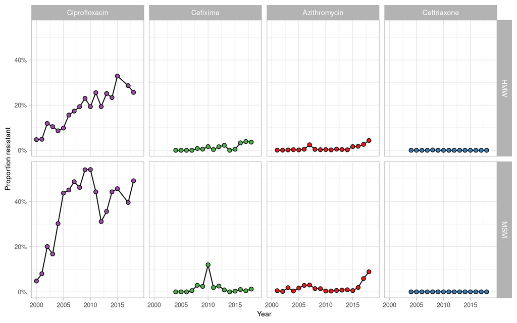

## MIC data

For each antibiotic, we also present the evolution of the MIC in time as a stacked area graph, more adapted to observe time trends (the “MIC drift”). For visualization purposes, we group together MIC classes that correspond to resistance according to the EUCAST thresholds.

### Ciprofloxacin

The interpretation of ciprofloxacin MIC data is hindered by a technical change in 2010.

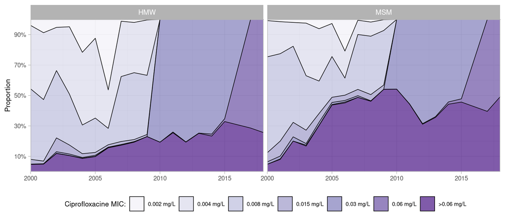

### Cefixime

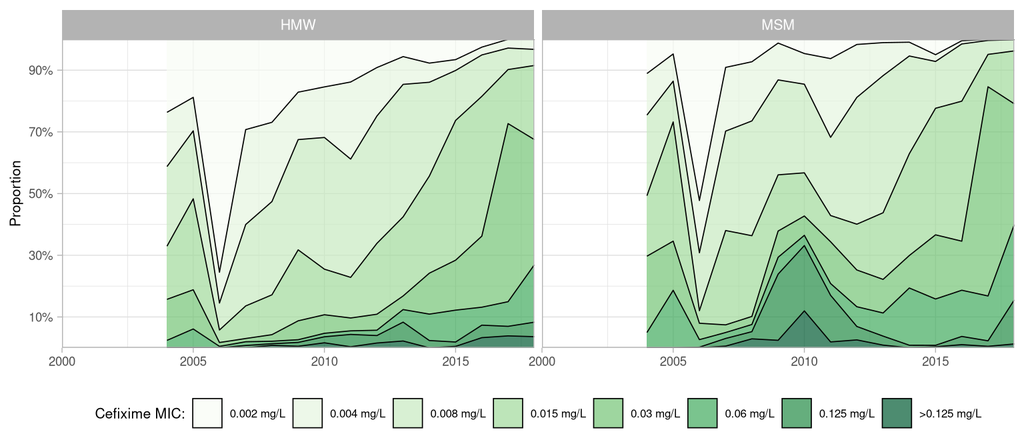

### Azithromycin

MIC levels for azithromycin appear relatively stable throughout the study period, with a sudden increase around 2015.

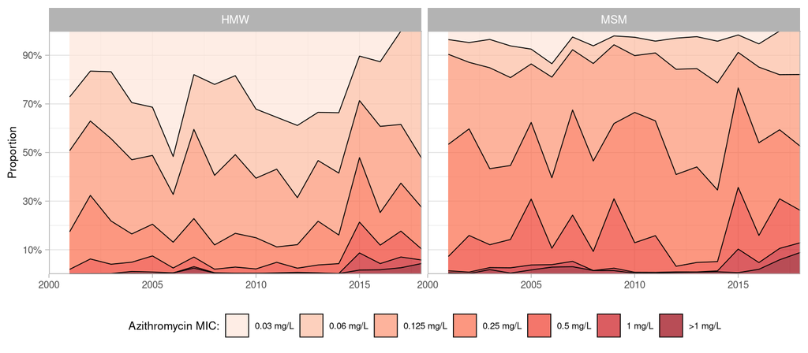

### Ceftriaxone

We observe a continuous MIC drift for ceftriaxone in both populations from 2005 on. As for cefixime, we also observe a temporary upward shift of MIC levels around 2009-2010 among MSM, that could be related to the circulation of the international clone.

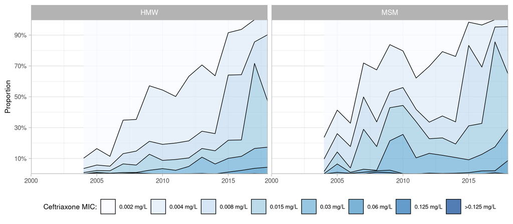